# IST 5535 HW10: Predicting Count of Bike Rentals

Sayantan Majumdar

2020-04-13

### Task A: Data Manipulation

#### 1. Read the dataset into a data frame. Show the structure of the dataset.

```r
data <- read.csv('DC_Bike_Rentals.csv')
str(data)
```

```
## 'data.frame':    10886 obs. of  10 variables:
##  $ hour      : int  0 1 2 3 4 5 6 7 8 9 ...
##  $ season    : int  1 1 1 1 1 1 1 1 1 1 ...
##  $ holiday   : int  0 0 0 0 0 0 0 0 0 0 ...
##  $ workingday: int  0 0 0 0 0 0 0 0 0 0 ...
##  $ weather   : int  1 1 1 1 1 2 1 1 1 1 ...
##  $ temp      : num  9.84 9.02 9.02 9.84 9.84 ...
##  $ atemp     : num  14.4 13.6 13.6 14.4 14.4 ...
##  $ humidity  : int  81 80 80 75 75 75 80 86 75 76 ...
##  $ windspeed : num  0 0 0 0 0 ...
##  $ count     : int  16 40 32 13 1 1 2 3 8 14 ...
```

```r
knitr::kable(summary(data))
```

|  | hour | season | holiday | workingday | weather | temp | atemp | humidity | windspeed | count |
| --- | --- | --- | --- | --- | --- | --- | --- | --- | --- | --- |
|  | Min. : 0.00 | Min. :1.000 | Min. :0.00000 | Min. :0.0000 | Min. :1.000 | Min. : 0.82 | Min. : 0.76 | Min. : 0.00 | Min. : 0.000 | Min. : 1.0 |
|  | 1st Qu.: 6.00 | 1st Qu.:2.000 | 1st Qu.:0.00000 | 1st Qu.:0.0000 | 1st Qu.:1.000 | 1st Qu.:13.94 | 1st Qu.:16.66 | 1st Qu.: 47.00 | 1st Qu.: 7.002 | 1st Qu.: 42.0 |
|  | Median :12.00 | Median :3.000 | Median :0.00000 | Median :1.0000 | Median :1.000 | Median :20.50 | Median :24.24 | Median : 62.00 | Median :12.998 | Median :145.0 |
|  | Mean :11.54 | Mean :2.507 | Mean :0.02857 | Mean :0.6809 | Mean :1.418 | Mean :20.23 | Mean :23.66 | Mean : 61.89 | Mean :12.799 | Mean :191.6 |
|  | 3rd Qu.:18.00 | 3rd Qu.:4.000 | 3rd Qu.:0.00000 | 3rd Qu.:1.0000 | 3rd Qu.:2.000 | 3rd Qu.:26.24 | 3rd Qu.:31.06 | 3rd Qu.: 77.00 | 3rd Qu.:16.998 | 3rd Qu.:284.0 |
|  | Max. :23.00 | Max. :4.000 | Max. :1.00000 | Max. :1.0000 | Max. :4.000 | Max. :41.00 | Max. :45.45 | Max. :100.00 | Max. :56.997 | Max. :977.0 |

#### 2. A very important step in predictive analytics is to represent different scales of measurement correctly in the dataset. What variables in the dataset should be represented as categorical variables? List them in the box. Transform those variables identified above into factors.

The categorial variables are season, holiday, workingday, and weather.

```r
data$season <- as.factor(data$season)
data$holiday <- as.factor(data$holiday)
data$workingday <- as.factor(data$workingday)
data$weather <- as.factor(data$weather)
str(data)
```

```
## 'data.frame':    10886 obs. of  10 variables:
##  $ hour      : int  0 1 2 3 4 5 6 7 8 9 ...
##  $ season    : Factor w/ 4 levels "1","2","3","4": 1 1 1 1 1 1 1 1 1 1 ...
##  $ holiday   : Factor w/ 2 levels "0","1": 1 1 1 1 1 1 1 1 1 1 ...
##  $ workingday: Factor w/ 2 levels "0","1": 1 1 1 1 1 1 1 1 1 1 ...
##  $ weather   : Factor w/ 4 levels "1","2","3","4": 1 1 1 1 1 2 1 1 1 1 ...
##  $ temp      : num  9.84 9.02 9.02 9.84 9.84 ...
##  $ atemp     : num  14.4 13.6 13.6 14.4 14.4 ...
##  $ humidity  : int  81 80 80 75 75 75 80 86 75 76 ...
##  $ windspeed : num  0 0 0 0 0 ...
##  $ count     : int  16 40 32 13 1 1 2 3 8 14 ...
```

#### 3. Use 30-70% data partition strategy, with 30% of data used as test data.

```r
library(caret)
library(parallel)
library(doParallel)
cl <- makePSOCKcluster(detectCores() - 1)
registerDoParallel(cl)

set.seed(0)
train_index <- createDataPartition(data$count, p = .7,
                                   list = F)
train_data <- data[train_index,]
test_data  <- data[-train_index,]
nrow(train_data)
```

```
## [1] 7622
```

```r
nrow(test_data)
```

```
## [1] 3264
```

### Task B: Predictive Modeling

#### 1. Train a regression tree to predict count of bike rental on the training set. Prune the regression tree by using a best parameter identified through a cross-validation. Train the pruned regression model.

##### Original regression tree

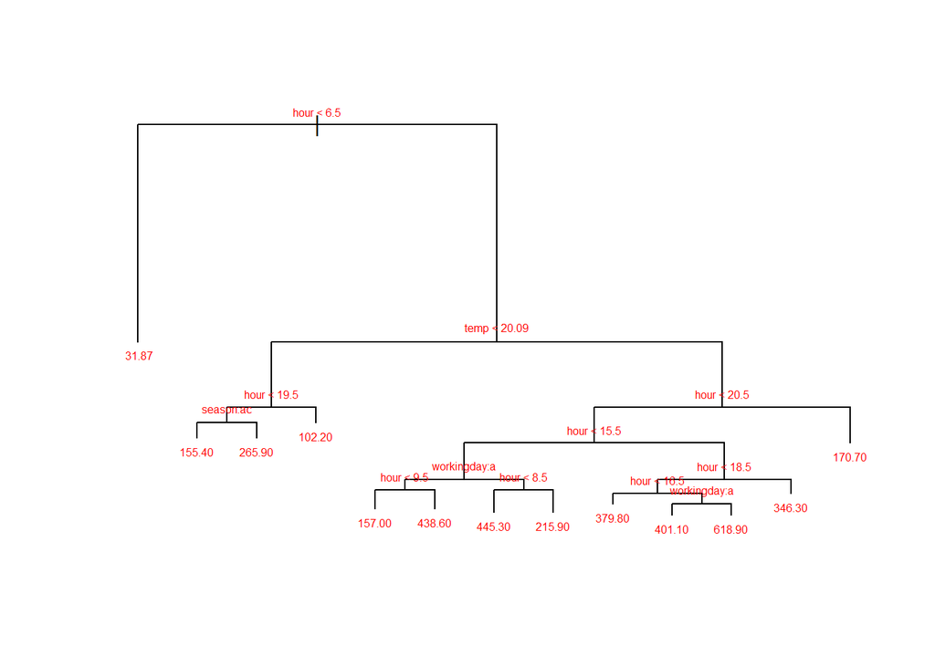

```r
library(tree)

count_rt <- tree(count ~ ., data = train_data)
plot(count_rt)
text(count_rt, cex = 0.5, col = 'red')
```

```r
summary(count_rt)
```

```
##
## Regression tree:
## tree(formula = count ~ ., data = train_data)
## Variables actually used in tree construction:
## [1] "hour"       "temp"       "season"     "workingday"
## Number of terminal nodes:  13
## Residual mean deviance:  10810 = 82250000 / 7609
## Distribution of residuals:
##    Min. 1st Qu.  Median    Mean 3rd Qu.    Max.
## -550.90  -51.15  -16.87    0.00   46.12  571.10
```

##### Pruned Regression Tree

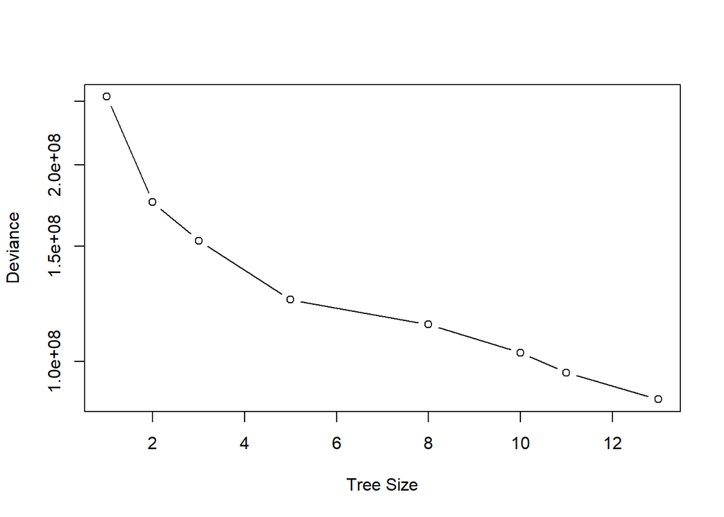

```r
cv_count <- cv.tree(count_rt)
plot(cv_count$size, cv_count$dev, type = 'b', log = 'y',
     xlab = 'Tree Size', ylab = 'Deviance')
```

Here, we see that for tree size = 13, the minimum deviance (number of misclassifcations) is obtained. So, there is no need to prune the decision tree.

#### 2. Train a random forest model to predict count of bike rental on the training set. Use a 10-fold cross-validation to run a parameter tuning process to find the optimal value of parameter “mtry”. Fit the final random forest model with the optimal mtry on the whole training set.

```r
library(randomForest)
count_rf <- randomForest(count ~ ., data = train_data,
                         mtry = 5, importance = T)
count_rf
```

```
##
## Call:
##  randomForest(formula = count ~ ., data = train_data, mtry = 5,      importance = T)
##                Type of random forest: regression
##                      Number of trees: 500
## No. of variables tried at each split: 5
##
##           Mean of squared residuals: 4866.576
##                     % Var explained: 85.4
```

```r
# num_predictors <- ncol(train_data) - 1
# tuneGrid <- data.frame(mtry = 1: num_predictors)
# print(tuneGrid)
# control <- trainControl(method = 'repeatedcv',
#                         number = 10, repeats = 1)
# set.seed(0)
# rf_tuned <- train(count ~ ., data = train_data,
#                   method = 'rf',
#                   trControl = control,
#                   tuneGrid = tuneGrid)
# print(rf_tuned)
# plot(rf_tuned)
```

##### Final RF model

```r
count_rf <- randomForest(count ~ ., data = train_data,
                         mtry = 9, importance = T)
count_rf
```

```
##
## Call:
##  randomForest(formula = count ~ ., data = train_data, mtry = 9,      importance = T)
##                Type of random forest: regression
##                      Number of trees: 500
## No. of variables tried at each split: 9
##
##           Mean of squared residuals: 4946.471
##                     % Var explained: 85.16
```

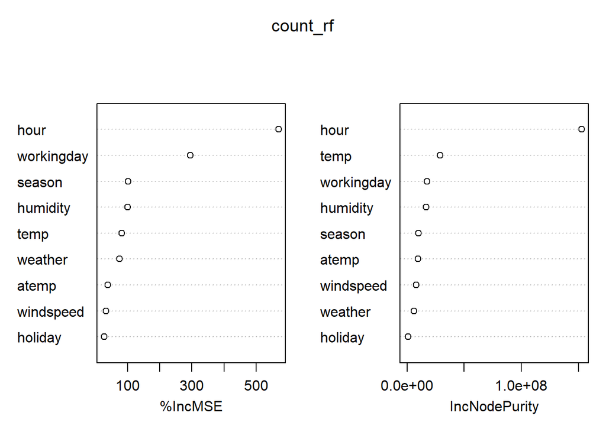

```r
varImpPlot(count_rf)
```

#### 3. Train a support vector machine model to predict count of bike rental on the training set. The svm() method in the e1071 can also be used for regression problems. Use a 10-fold cross-validation to run a parameter tuning process to find the optimal kernel among linear, RBF, and polynomial kernels. Fit the final SVM model with the optimal kernel on the whole training set.

```r
library(e1071)

preprocessParams <- preProcess(train_data,
                               method =
                                 c("scale", "center"))
print(preprocessParams)
```

```
## Created from 7622 samples and 10 variables
##
## Pre-processing:
##   - centered (6)
##   - ignored (4)
##   - scaled (6)
```

```r
train_scaled <- predict(preprocessParams, train_data)
test_scaled <- predict(preprocessParams, test_data)

svm_cv <- function(data, response, num_folds, kernel_type) {
  set.seed(0)
  f <- as.formula(paste(response, '~ .'))
  if (kernel_type == 'radial') {
  tune_svm <- tune(svm, f, data = train_scaled,
                   kernel = 'radial',
                   tunecontrol =
                     tune.control(
                       cross = num_folds,
                       sampling = "cross"),
                   ranges = list(cost = 10 ^ (-2: 2),
                                 gamma = 10 ^ (-2: 2)))
  } else if (kernel_type == 'linear') {
    tune_svm <- tune(svm, f, data = train_scaled,
                     kernel = 'linear',
                     tunecontrol =
                       tune.control(
                         cross = num_folds,
                         sampling = "cross"),
                     ranges = list(cost = 10 ^ (-2: 2)))
  } else {
    tune_svm <- tune(svm, f, data = train_scaled,
                     kernel = 'polynomial',
                     degree = 2,
                     tunecontrol =
                       tune.control(
                         cross = num_folds,
                         sampling = "cross"),
                     ranges = list(cost = 10 ^ (-2: 2)))
  }
  print(summary(tune_svm))
  print(tune_svm$best.parameters)
  print(tune_svm$best.performance)
  return(tune_svm)
}

svm_cv_caret <- function(data, response, num_folds, repeats, kernel_type) {
  set.seed(0)
  f <- as.formula(paste(response, '~ .'))
  tuneGrid <- data.frame(C = 10 ^ (-2: 2))
  if (kernel_type == 'svmRadial') {
    tuneGrid <- data.frame(C = 10 ^ (-2: 2),
                           sigma = 10 ^ (-2: 2))
  } else if (kernel_type == 'svmPoly') {
    tuneGrid <- data.frame(C = 10 ^ (-2: 2),
                           degree = (1: 5),
                           scale = 10 ^ (-4: 0))
  }
  print(tuneGrid)
  control <- trainControl(method = 'repeatedcv',
                          number = num_folds,
                          repeats = repeats)
  svm_tuned <- train(f, data = train_data,
                     method = kernel_type,
                     trControl = control,
                     tuneGrid = tuneGrid)
  print(svm_tuned)
  print(svm_tuned$bestTune)
  plot(svm_tuned)
  return(svm_tuned)
}
```

##### Linear Kernel

```r
# tune_svm_linear <- svm_cv_caret(train_scaled, 'count',
#                                 10, 1, 'svmLinear')
```

##### Radial (RBF) Kernel

```r
# tune_svm_radial <- svm_cv_caret(train_scaled, 'count',
#                                 10, 1, 'svmRadial')
```

##### Polynomial Kernel

```r
# tune_svm_poly <- svm_cv_caret(train_scaled, 'count',
#                         10, 1, 'svmPoly')
```

##### Final SVM Model

```r
count_svm <- svm(count ~ ., data = train_scaled,
                 kernel = 'radial', cost = 1, gamma = 1,
                 scale = T)
```

#### 4. Use test dataset to evaluate the performance of your final models. Organize model comparison in a data frame.

##### Pruned Decision Tree Performance

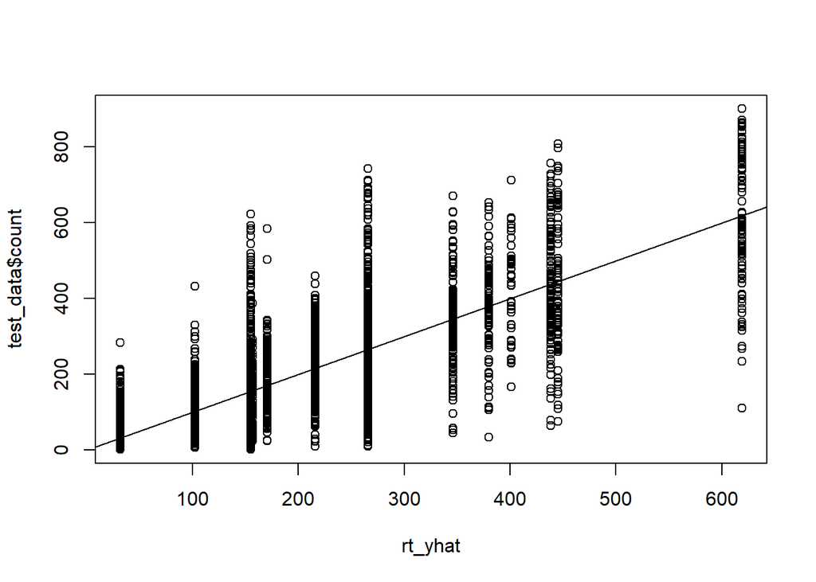

```r
rt_yhat <- predict(count_rt, newdata = test_data)
rt_results <- postResample(rt_yhat, test_data$count)
plot(rt_yhat, test_data$count)
abline(0, 1)
```

##### Random Forest Performance

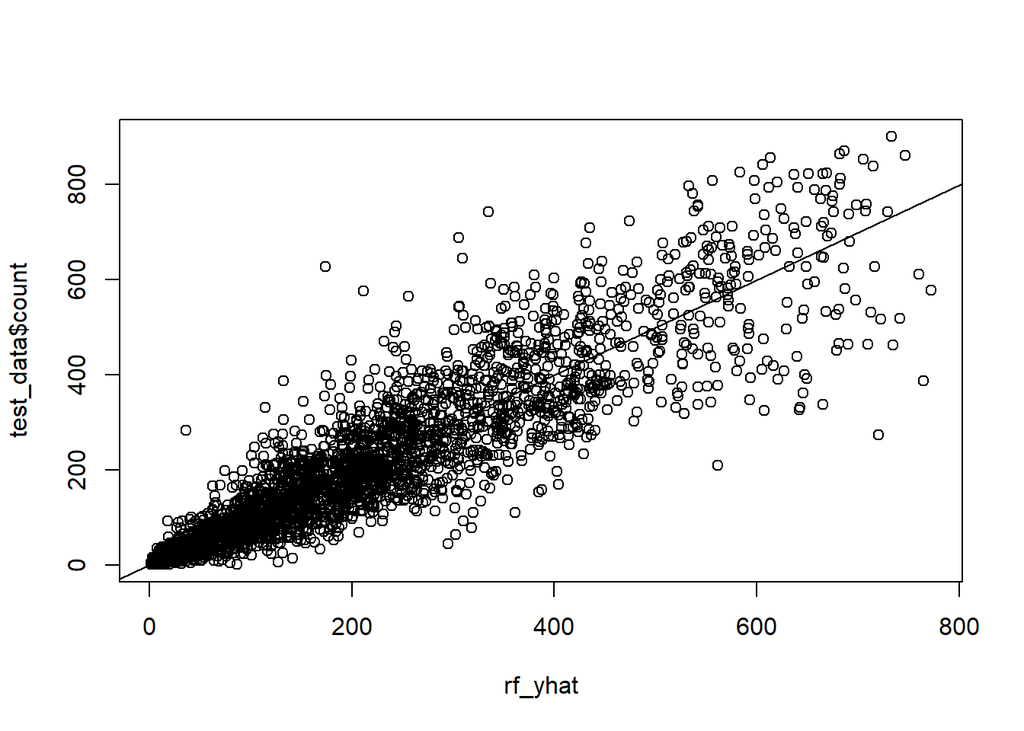

```r
rf_yhat <- predict(count_rf, newdata = test_data)
rf_results <- postResample(rf_yhat, test_data$count)
plot(rf_yhat, test_data$count)
abline(0, 1)
```

##### SVM Performance

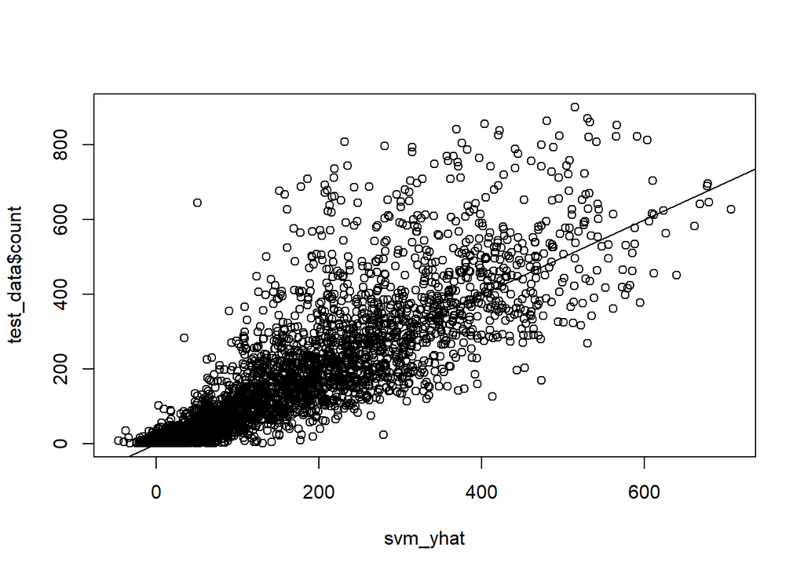

```r
svm_yhat <- predict(count_svm, newdata = test_scaled)
svm_yhat <- svm_yhat * sd(train_data$count) + mean(train_data$count)
svm_results <- postResample(svm_yhat, test_data$count)
plot(svm_yhat, test_data$count)
abline(0, 1)
```

##### Model Evaluation

```r
final_df = data.frame(Model =
                        c('Pruned Regression Tree',
                          'Random Forests', 'SVM'),
                          RMSE = c(rt_results[["RMSE"]],
                                   rf_results[["RMSE"]],
                                   svm_results[["RMSE"]]),
                          R2 = c(rt_results[["Rsquared"]],
                                 rf_results[["Rsquared"]],
                                 svm_results[["Rsquared"]]),
                          MAE = c(rt_results[["MAE"]],
                                  rf_results[["MAE"]],
                                  svm_results[["MAE"]]))
print(final_df)
```

```
##                    Model      RMSE        R2      MAE
## 1 Pruned Regression Tree 105.04345 0.6512985 74.09420
## 2         Random Forests  71.09708 0.8402043 47.10533
## 3                    SVM 101.01874 0.6853130 63.59245
```

```r
stopCluster(cl)
```